# Can we understand the distribution of a variable using music?

Author

Affiliation

Donya Behroozi, Dr. Julia Schedler, Dr. Sinem Demirci

Statistics Department, Bailey College of Science and Mathematics

## Do your ear and eye perceive the same information about a distribution?

Using the ggplot2 package (2016) in R (2021), we visualized 5 different variables containing data about the Central Coast area. Each distribution has a different shape, which you can see by looking at the histogram of each variable.

Each of the lines on the histogram represents the cutoff for 25% of the data, which gives us a five number summary.

Color Legend

| Statistic in 5 Number Summary | Meaning |
| --- | --- |
| Minimum | smallest value in the data set |
| Q1 | upper limit of smallest 25% of data values |
| Median | middle value (50% of data values above and below this number) |
| Q3 | lower limit of largest 25% of data values |
| Maximum | the largest value in the data set |

Using the gm package (Mao 2024) to create sonifications by first finding the five number summary for each distribution, then converting those numbers to music. Sonification is the use of non-speech audio to covey information (Hermann et al. 2011).

Our sonifications are based on the method of Flowers (1993). First, a leading tone for the middle of the distribution is played first, then the 5 number summary.

Do your ear and your eye agree? Scroll down and compare the visualizations to the sonifications!

### Severe Heat Incidence

Percentage of census tracts that are hotter than the average temperature for the entire city.

[figure not shown]

[interactive chart not shown]

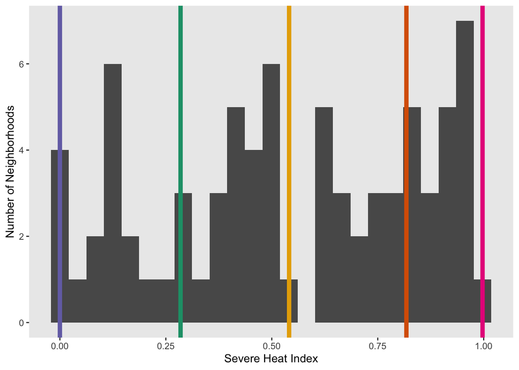

### Percent of Population in poverty

Specifically, the percentage of the population living below two times the federal poverty level.

[figure not shown]

[interactive chart not shown]

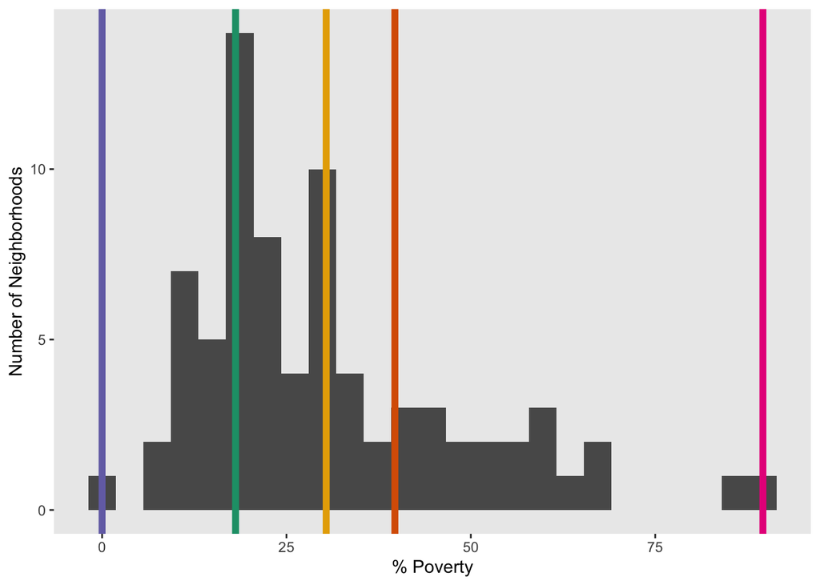

### Asthma-related emergency visits

Specifically, the age-adjusted rate of emergency department visits for asthma.

[figure not shown]

[interactive chart not shown]

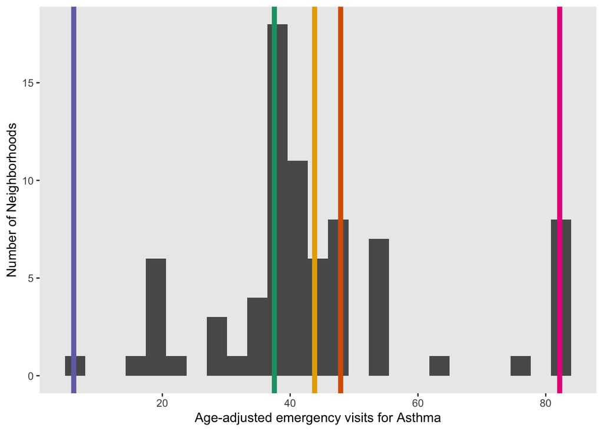

### Annual Average Air Pollution

Specifically, the annual mean concentration of particulate matter in the air for the given region.

[figure not shown]

[interactive chart not shown]

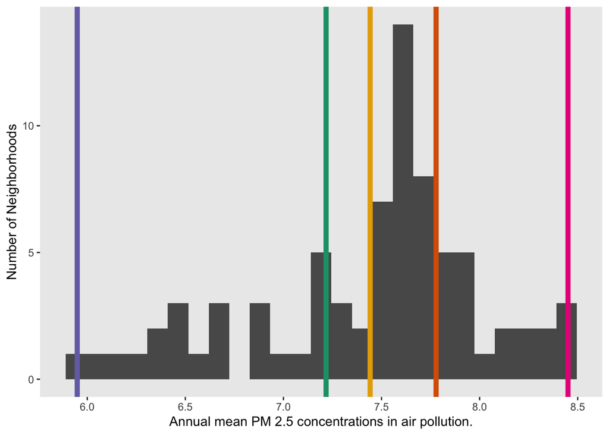

### % Tree Canopy Cover

The percentage of area with tree canopy cover in 2018.

[figure not shown]

[interactive chart not shown]

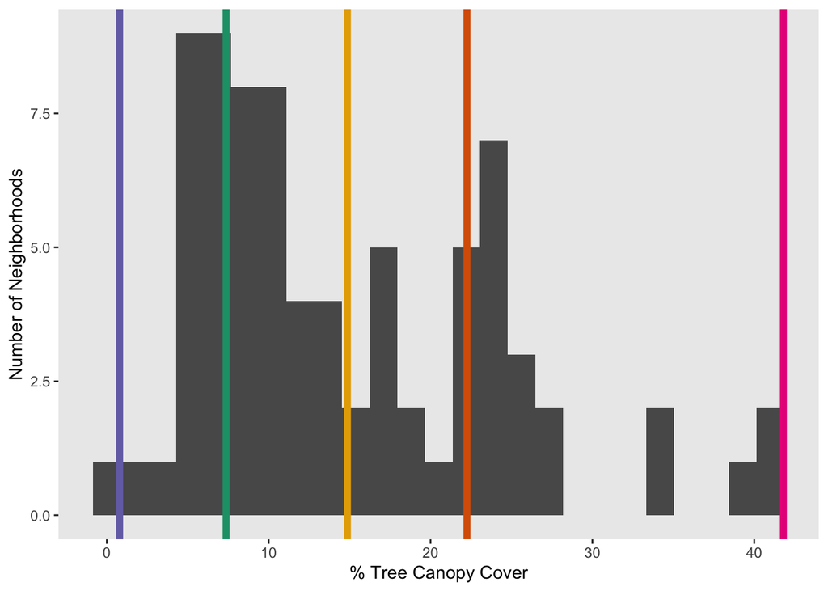

## Playing all Variables at Once

There is no singular way to visualize all 5 variables at once, since we can only use 3 spatial dimensions for a visual. What do they all *sound* like played together?

[figure not shown]

[interactive chart not shown]

## Learning more

Contact Dr. Julia Schedler with questions or comments! Thanks for perceiving!

## References

Flowers, John H., and Terry A. Hauer. 1993. “‘Sound’ Alternatives to Visual Graphics for Exploratory Data Analysis.” *Behavior Research Methods, Instruments, & Computers* 25 (2): 242–49. https://doi.org/10.3758/BF03204505.

Hermann, Thomas, Andrew Hunt, John G. Neuhoff, and Europäische Zusammenarbeit auf dem Gebiet der Wissenschaftlichen und Technischen Forschung, eds. 2011. *Ch02-The Sonification Handbook*. Berlin: Logos Verlag. https://sonification.de/handbook/.

Mao, Renfei. 2024. “Gm: Create Music with Ease.” https://cran.r-project.org/web/packages/gm/index.html.

R Core Team. 2021. *R: A Language and Environment for Statistical Computing*. Vienna, Austria: R Foundation for Statistical Computing. https://www.R-project.org/.

Wickham, Hadley. 2016. *Ggplot2: Elegant Graphics for Data Analysis*. Springer-Verlag New York. https://ggplot2.tidyverse.org.